# Assignment 12/04

# Chapter 17 Regression

Up to this point, this book has focused mainly on single variables. However, in data science applications, it is very common to be interested in the relationship between two or more variables. For instance, in Chapter 18 we will use a data-driven approach that examines the relationship between player statistics and success to guide the building of a baseball team with a limited budget. Before delving into this more complex example, we introduce necessary concepts needed to understand regression using a simpler illustration. We actually use the dataset from which regression was born.

The example is from genetics. Francis Galton59 studied the variation and heredity of human traits. Among many other traits, Galton collected and studied height data from families to try to understand heredity. While doing this, he developed the concepts of correlation and regression, as well as a connection to pairs of data that follow a normal distribution. Of course, at the time this data was collected our knowledge of genetics was quite limited compared to what we know today. A very specific question Galton tried to answer was: how well can we predict a child’s height based on the parents’ height? The technique he developed to answer this question, regression, can also be applied to our baseball question. Regression can be applied in many other circumstances as well.

**Historical note**: Galton made important contributions to statistics and genetics, but he was also one of the first proponents of eugenics, a scientifically flawed philosophical movement favored by many biologists of Galton’s time but with horrific historical consequences. You can read more about it here: https://pged.org/history-eugenics-and-genetics/.

## 17.1 Case study: is height hereditary?

```r
install.packages("HistData")
```

In the exercises, we will look at other relationships including mothers and daughters.

Suppose we were asked to summarize the father and son data. Since both distributions are well approximated by the normal distribution, we could use the two averages and two standard deviations as summaries:

| mean(father) | sd(father) | mean(son) | sd(son) |
| --- | --- | --- | --- |
| 69.09888 | 2.546555 | 69.16927 | 2.710965 |

However, this summary fails to describe an important characteristic of the data: the trend that the taller the father, the taller the son.

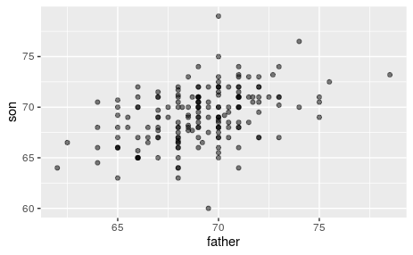

We will learn that the correlation coefficient is an informative summary of how two variables move together and then see how this can be used to predict one variable using the other.

## 17.2 The correlation coefficient

The correlation coefficient is defined for a list of pairs (x1,y1),…,(xn,yn) as the average of the product of the standardized values:

```r
rho <- mean(scale(x) * scale(y))
```

```r
galton_heights %>% summarize(r = cor(father, son)) %>% pull(r)
```

```
[1] 0.4334102
```

### 17.2.1 Sample correlation is a random variable

Before we continue connecting correlation to regression, let’s remind ourselves about random variability.

In most data science applications, we observe data that includes random variation. For example, in many cases, we do not observe data for the entire population of interest but rather for a random sample. As with the average and standard deviation, the *sample correlation* is the most commonly used estimate of the population correlation. This implies that the correlation we compute and use as a summary is a random variable.

`R` is a random variable. We can run a Monte Carlo simulation to see its distribution:

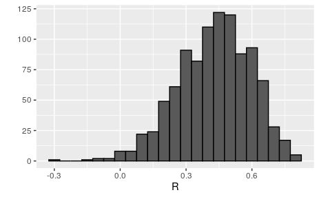

We see that the expected value of `R` is the population correlation:

```r
mean(R)
```

```
[1] 0.4291816
```

and that it has a relatively high standard error relative to the range of values `R` can take:

```r
sd(R)
```

```
[1] 0.1663783
```

So, when interpreting correlations, remember that correlations derived from samples are estimates containing uncertainty.

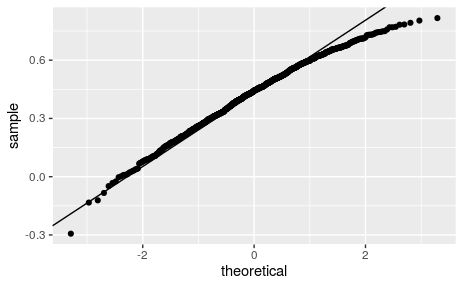

If you increase N , you will see the distribution converging to normal.

### 17.2.2 Correlation is not always a useful summary

Correlation is only meaningful in a particular context. To help us understand when it is that correlation is meaningful as a summary statistic, we will return to the example of predicting a son’s height using his father’s height. This will help motivate and define linear regression. We start by demonstrating how correlation can be useful for prediction.